# Manual de Administrador — Camp Manager

Fecha de publicación

19 de junio de 2026

# Prefacio

**Camp Manager** es una plataforma para gestionar campamentos: clubes, eventos, jueces, calificaciones y reportes. Este manual cubre todas las funciones disponibles para usuarios con rol **admin**.

**URL de producción:** https://campmanager.lirasprod.com/

## Requisitos previos

- Credenciales con rol `admin`
- La mayoría de módulos requieren tener un **campamento activo seleccionado** (se elige al iniciar sesión o desde la barra lateral)

## Módulos cubiertos

| # | Módulo | Descripción |
| --- | --- | --- |
| 1 | Login y Acceso | Autenticación y selección de campamento activo |
| 2 | Campamentos | Crear campamentos, publicar calificaciones |
| 3 | Clubes | Registrar clubes, importación masiva desde Excel/CSV |
| 4 | Usuarios | Gestionar jueces, invitaciones, reset de contraseñas |
| 5 | Directores | Gestionar cuentas del portal de directores |
| 6 | Eventos | Crear eventos, rúbricas y asignar jueces |
| 7 | Reportes | 11 dashboards de análisis, ranking y seguimiento |
| 8 | Configuración | Organizaciones y afiliaciones (zonas/regiones) |

*Capturas tomadas desde producción: https://campmanager.lirasprod.com/*

# 1. Login y Acceso

**URL del sistema:** https://campmanager.lirasprod.com/

## 1.1 Iniciar sesión

1. Abre el navegador y accede a https://campmanager.lirasprod.com/
2. Ingresa tu **usuario** y **contraseña** en los campos correspondientes
3. Haz clic en el botón **Login**

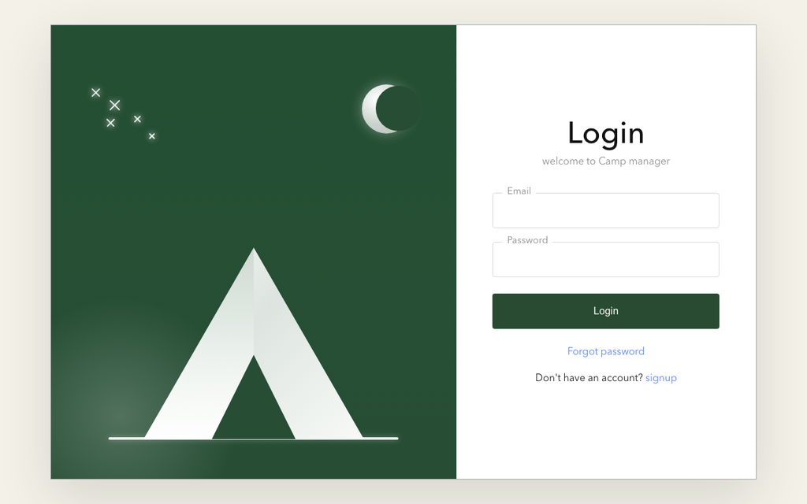

Formulario de login

**Nota**

El campo superior se llama “Email” pero acepta el nombre de usuario.

## 1.2 Error de credenciales

Si los datos son incorrectos, el sistema muestra el mensaje **“Login failed. Please check your credentials.”** en la parte superior del formulario. Verifica usuario y contraseña e intenta nuevamente.

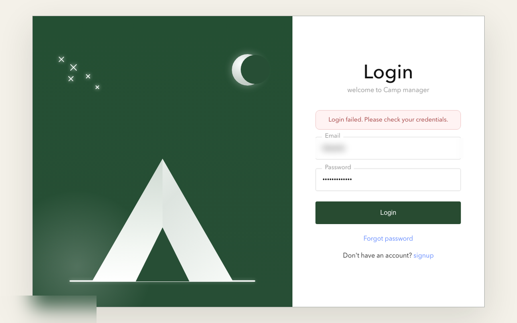

Error de credenciales

## 1.3 Selección de campamento

Al autenticarte correctamente, el sistema muestra automáticamente el diálogo **“Seleccionar Campamento”** para elegir con qué campamento deseas trabajar en esta sesión.

- Haz clic sobre el nombre del campamento para seleccionarlo
- Si aún no existe ninguno, usa el botón **“+ Crear Campamento”**

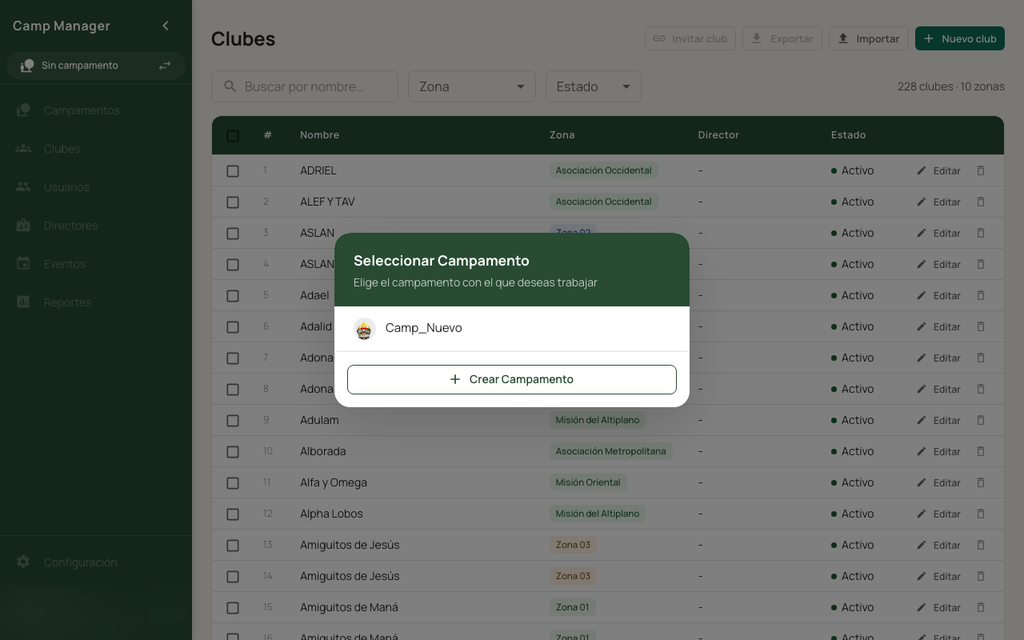

Selector de campamento

**Importante**

La mayoría de módulos (Clubes, Usuarios, Directores, Eventos, Reportes) muestran datos filtrados por el campamento activo. Es importante seleccionar el campamento correcto antes de operar.

## 1.4 Vista principal

Una vez seleccionado el campamento, el sistema carga la vista principal. En la barra lateral izquierda encontrarás:

- El **nombre del campamento activo** en la parte superior del menú
- Los módulos de navegación: Campamentos, Clubes, Usuarios, Directores, Eventos, Reportes y Configuración
- En la esquina inferior: tu **nombre de usuario** y el botón de **cerrar sesión** (ícono de salida)

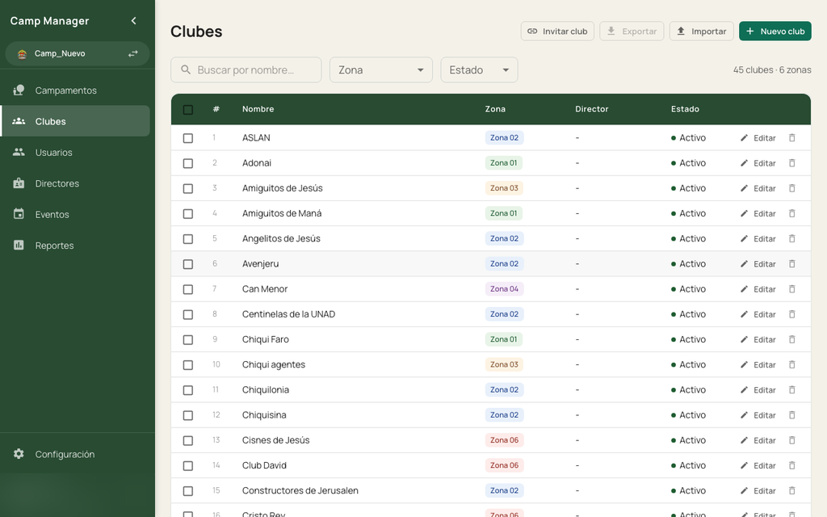

Vista principal con campamento seleccionado

## 1.5 Cambiar de campamento

Para cambiar el campamento activo sin cerrar sesión:

1. En la barra lateral, haz clic en el ícono de **flechas** (↔︎) junto al nombre del campamento activo
2. Se abre nuevamente el diálogo “Seleccionar Campamento”
3. Elige el nuevo campamento

## 1.6 Cerrar sesión

El botón de cierre de sesión se encuentra en la **esquina inferior izquierda** de la barra lateral (ícono de salida, junto a tu nombre de usuario). Al hacer clic, la sesión finaliza y regresas a la pantalla de login.

**Nota**

La sesión tiene una duración de **7 días**. Pasado ese tiempo, el sistema solicita volver a autenticarse.

## 1.7 Primer acceso (cambio de contraseña obligatorio)

Si es la primera vez que ingresas al sistema (o un administrador reseteó tu contraseña), el sistema solicitará que **cambies tu contraseña** antes de continuar. Ingresa la contraseña temporal recibida y define una nueva contraseña.

# 2. Campamentos

Los campamentos son la unidad principal del sistema. Cada módulo (clubes, eventos, reportes) trabaja en el contexto del campamento activo seleccionado.

## 2.1 Ver campamentos

La lista muestra todos los campamentos del sistema con sus columnas:

| Columna | Descripción |
| --- | --- |
| **Logo** | Imagen identificadora del campamento |
| **Nombre** | Nombre del campamento |
| **Fecha Inicio / Fin** | Rango de fechas del evento |
| **Activo** | Toggle para activar/desactivar el campamento |
| **Calificaciones** | Estado de publicación: `Sin publicar` o `Publicado` con fecha |

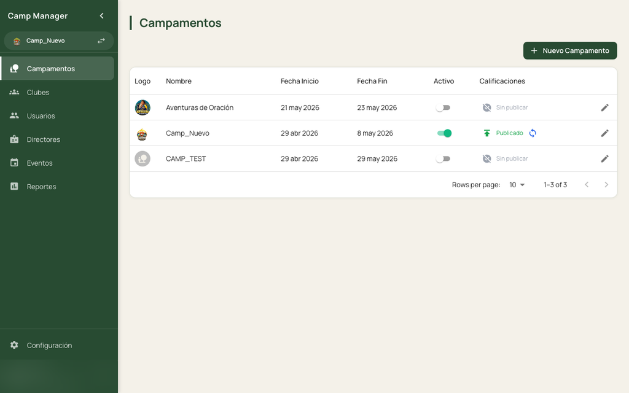

Lista de campamentos

**Tip**

El campamento activo en la sesión actual aparece resaltado en la barra lateral (esquina superior izquierda). Para cambiarlo, usa el ícono ↔︎ junto al nombre.

## 2.2 Crear campamento

1. Haz clic en **“+ Nuevo Campamento”** (esquina superior derecha)
2. Completa los campos del formulario:
   - **Nombre** *(obligatorio)* — nombre del campamento
   - **Fecha de Inicio / Fecha de Fin** *(obligatorio)* — rango de fechas
   - **Logo** — clic en “Subir logo” para cargar una imagen
   - **Organización** *(opcional)* — selecciona la organización/afiliación padre
   - **Clasificación de Ranking** — define las categorías con su puntaje mínimo (Desde %):
     - El sistema incluye un preset: *Excelencia (90%), Honorable (79%), Sobresaliente (61%), Participación (0%)*
     - Puedes agregar, editar o eliminar categorías según necesidad
3. Haz clic en **“Guardar”** para crear el campamento

[figure not shown]

Formulario de nuevo campamento

## 2.3 Editar campamento

1. En la fila del campamento, haz clic en el ícono de lápiz (✏️) a la derecha
2. Se abre el mismo formulario con los datos actuales precargados
3. Modifica los campos necesarios y haz clic en **“Guardar”**

[figure not shown]

Formulario de edición de campamento

**Nota**

La edición no afecta calificaciones ya registradas. Solo modifica los metadatos del campamento.

## 2.4 Activar / desactivar campamento

El toggle en la columna **“Activo”** controla si el campamento aparece disponible para los jueces en la app móvil.

- **Activo (verde):** el campamento es visible para los jueces
- **Inactivo (gris):** el campamento está oculto para los jueces, pero el admin puede seguir operando sobre él

**Nota**

Solo el campamento **seleccionado en tu sesión** es el que ves activo en la barra lateral. El toggle “Activo” es independiente — un admin puede tener seleccionado un campamento inactivo para administrarlo.

## 2.5 Publicar calificaciones

Publicar hace visible el snapshot de calificaciones para los directores en su portal.

1. En la columna **“Calificaciones”**, haz clic en **“Sin publicar”** del campamento que deseas publicar
2. Aparece el diálogo de confirmación con el texto: *“Los directores de ‘[Nombre]’ verán las calificaciones actuales. Esta acción captura un snapshot de las notas en este momento.”*
3. Haz clic en **“Publicar ahora”** para confirmar

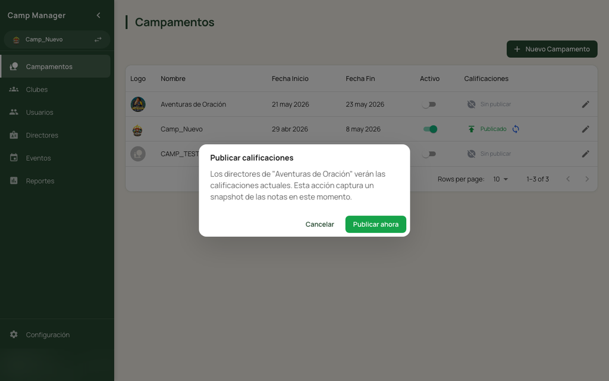

Diálogo de publicar calificaciones

Para **retirar la publicación**, haz clic en “Publicado” y confirma con **“Retirar”**.

**Nota**

Publicar no bloquea los datos — los jueces pueden seguir calificando. Solo captura el estado actual para los directores.

## 2.6 Sincronizar calificaciones

El ícono 🔄 junto a “Publicado” permite **actualizar el snapshot** sin retirar la publicación.

- Úsalo cuando los jueces hayan registrado nuevas calificaciones y quieras que los directores vean los datos actualizados
- No requiere des-publicar y volver a publicar

# 3. Clubes

Los clubes son los grupos participantes del campamento. Cada club pertenece a una afiliación (zona/región) y tiene asignado un director.

## 3.1 Ver clubes

La lista muestra todos los clubes del campamento activo con sus columnas:

| Columna | Descripción |
| --- | --- |
| **Nombre** | Nombre del club |
| **Director** | Persona responsable del club |
| **Zona** | Afiliación a la que pertenece (color por zona) |
| **Estado** | Punto verde = Activo · Gris = Inactivo |
| **Acciones** | Botones de editar y deshabilitar |

### Filtros disponibles

Encima de la tabla encontrarás tres controles:

- **Buscar por nombre** — búsqueda en tiempo real conforme escribes
- **Zona** — filtra por afiliación/zona
- **Estado** — filtra entre Activo, Inactivo o todos

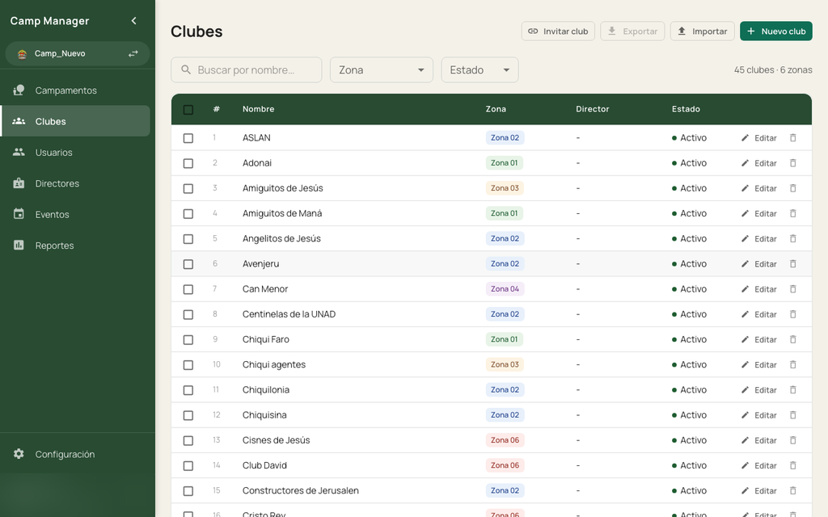

Lista de clubes

## 3.2 Crear club

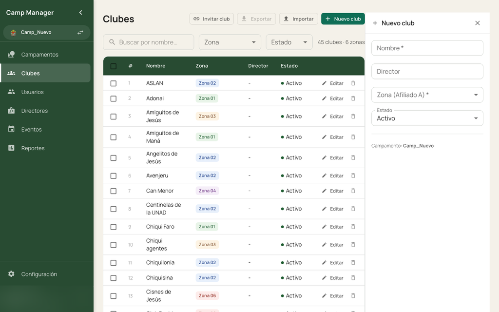

Formulario de creación de club

## 3.3 Editar club

1. En la fila del club, haz clic en el ícono de lápiz (**Editar**)
2. Se abre el formulario con los datos actuales precargados
3. Modifica los campos necesarios y haz clic en **“Guardar”**

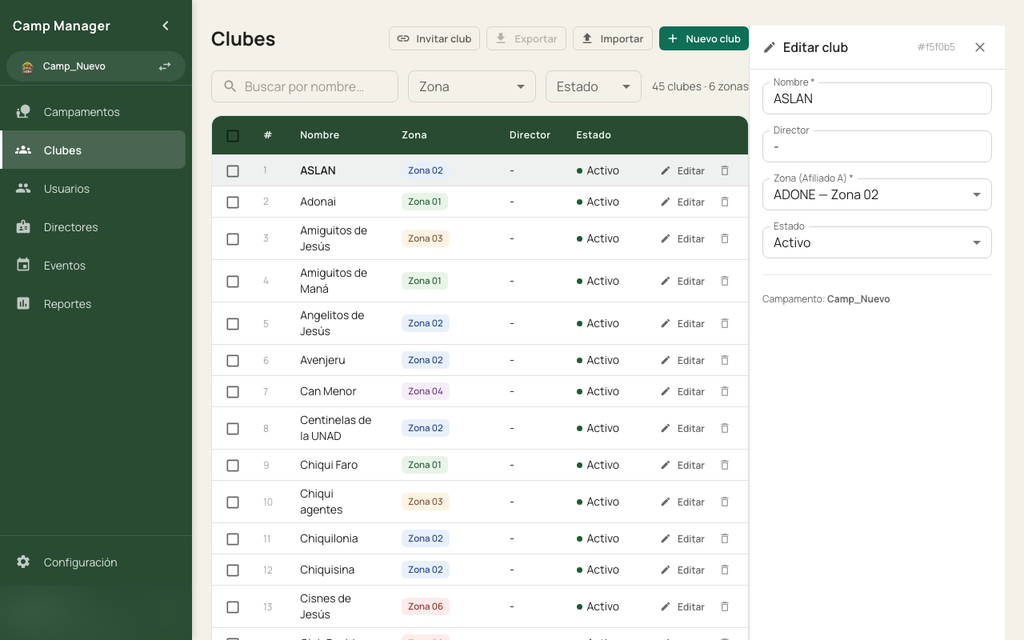

Formulario de edición de club

## 3.4 Deshabilitar club

El ícono de papelera junto al lápiz realiza un **soft-delete**: cambia el estado del club a Inactivo sin eliminar los datos.

1. Haz clic en el ícono de papelera de la fila correspondiente
2. Se abre un diálogo de confirmación con los datos del club
3. Haz clic en **“Deshabilitar”** para confirmar

**Tip**

Los clubes deshabilitados no aparecen en la app móvil para los jueces. Puedes reactivarlos editando el club y cambiando el Status a Activo.

## 3.5 Importación masiva

El botón **“Importar”** abre un wizard de 3 pasos para cargar múltiples clubes desde un archivo Excel o CSV.

### Paso 1 — Subir archivo

- Arrastra el archivo al área indicada o haz clic para seleccionarlo
- Formatos aceptados: `.xlsx`, `.xls`, `.csv`
- El sistema lee los encabezados y filas automáticamente
- Si el archivo supera 1,000 filas, aparece un aviso de que la importación puede tardar unos segundos
- Para no partir de cero, descarga la **plantilla Excel** con el botón “Descargar plantilla Excel”

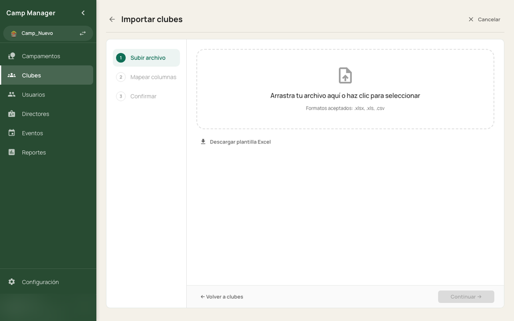

Wizard - Paso 1: subir archivo

### Paso 2 — Mapear columnas

El sistema detecta automáticamente qué columna del archivo corresponde a cada campo, reconociendo aliases en español e inglés:

| Campo del sistema | Aliases detectados automáticamente |
| --- | --- |
| Nombre* | `nombre`, `name`, `club`, `nombre del club` |
| Director | `director`, `lider`, `líder`, `leader` |
| Zona (Afiliado A)* | `zona`, `zone`, `afiliacion`, `afiliado a` |
| Estado | `estado`, `status`, `activo`, `active` |

Si la detección no es correcta, usa el desplegable de cada fila para asignar la columna manualmente. Los campos marcados con `*` son obligatorios para continuar.

[figure not shown]

### Paso 3 — Confirmar

Antes de importar, el sistema muestra:

- **Tarjetas de resumen**: total de clubes a importar, cuántos no tienen director y cuántas zonas distintas fueron detectadas
- **Vista previa** de las primeras 5 filas con nombre, director, zona y estado
- **Advertencia** si alguna fila tiene errores (nombre vacío o zona no reconocida) — se importarán igual y podrás editarlas después

Haz clic en **“Importar N clubes”** para confirmar. Al terminar, el sistema redirige automáticamente a la lista de clubes.

[figure not shown]

**Advertencia**

Si la zona de un club no coincide con ninguna afiliación registrada, la fila se marca como advertencia (fondo amarillo). El club se importa igualmente sin afiliación asignada.

## 3.6 Invitar club

El botón **“Invitar club”** genera un link de registro que puedes compartir con el director del club para que se registre e ingrese al campamento.

1. Haz clic en **“Invitar club”**
2. Se abre un diálogo con el link generado
3. Copia el link y compártelo con el director del club

**Nota**

El link es específico al campamento activo. El director lo usará para registrarse o iniciar sesión y quedará vinculado automáticamente al campamento.

# 4. Usuarios (Jueces)

Los usuarios con rol **Basic** son los jueces que califican eventos desde la app móvil. Desde esta sección puedes ver quiénes están registrados en el campamento activo, invitar nuevos jueces, crear cuentas directamente y gestionar sus rúbricas asignadas.

## 4.1 Ver usuarios

La tabla muestra todos los usuarios vinculados al campamento activo con las siguientes columnas:

| Columna | Descripción |
| --- | --- |
| *(expandir)* | Ícono de flecha para ver las rúbricas asignadas al juez |
| **Nombre** | Nombre completo del usuario |
| **UserName** | Nombre de usuario para iniciar sesión |
| **Email** | Correo electrónico (opcional) |
| **Role** | Rol del usuario: `admin` o `Basic` (juez) |

Encima de la tabla hay una caja de búsqueda que filtra por nombre, usuario o rol en tiempo real.

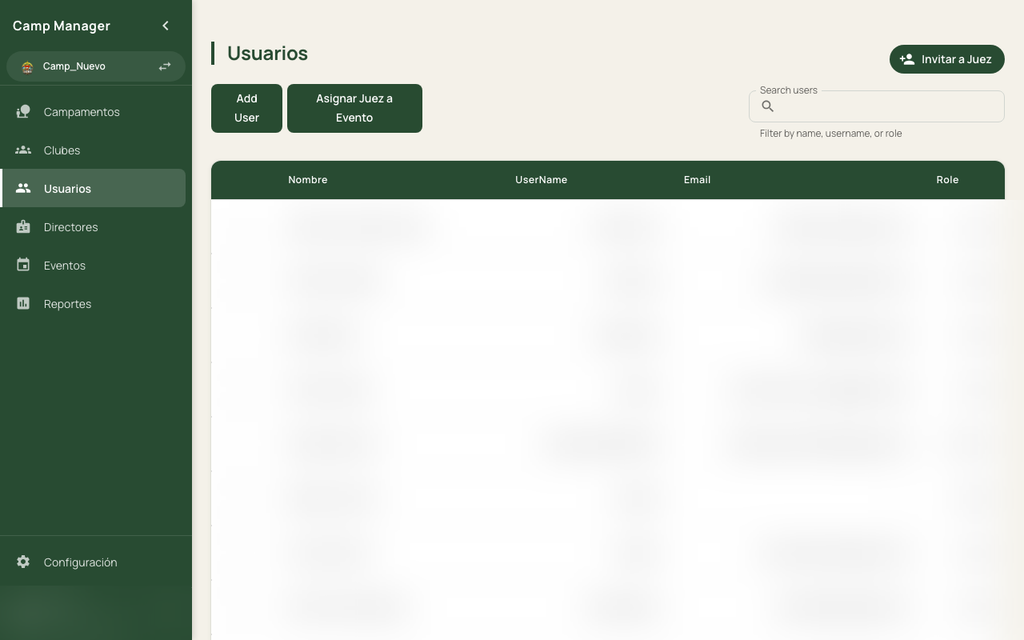

Lista de usuarios

## 4.2 Invitar juez

Genera un link único del campamento para que el juez se registre o inicie sesión por su cuenta.

1. Haz clic en **“Invitar a Juez”** (esquina superior derecha)
2. Se abre un diálogo con el link de invitación
3. Haz clic en **“Copiar enlace”** para copiarlo al portapapeles
4. Comparte el link con el juez por el medio que prefieras (WhatsApp, correo, etc.)

Al abrir el link, el juez verá el formulario de registro o login vinculado al campamento activo.

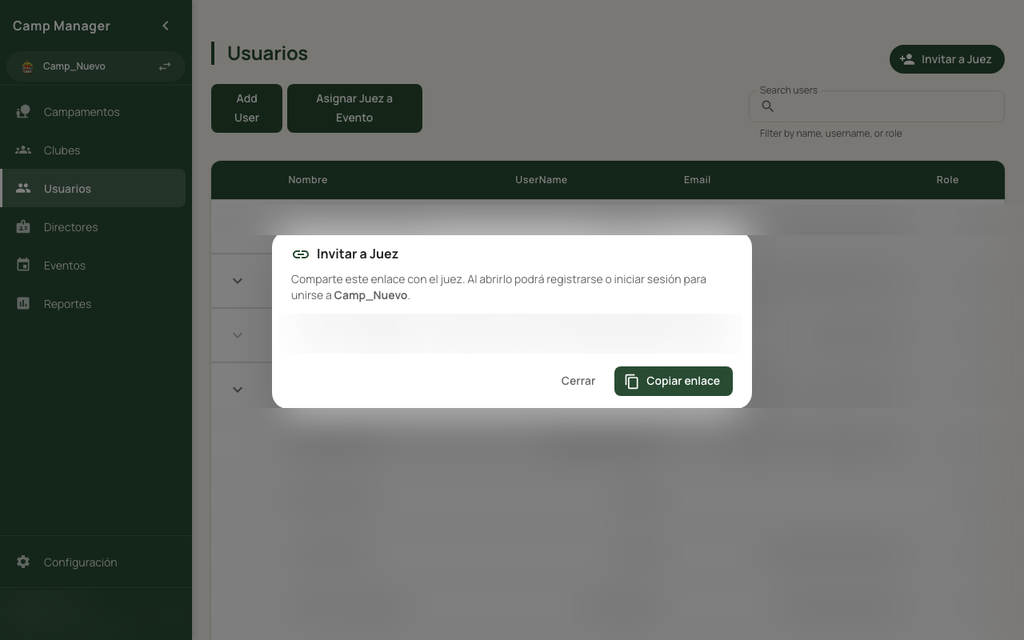

Diálogo de invitación

**Nota**

El link es específico al campamento activo. Si cambias de campamento en la barra lateral, el link generado corresponderá al nuevo campamento seleccionado.

## 4.3 Crear usuario directamente

Además del link de invitación, puedes crear la cuenta del juez tú mismo:

1. Haz clic en **“Add User”** (sobre la tabla)
2. Completa los campos:
   - **Nombre Completo** *(obligatorio)*
   - **Usuario** *(obligatorio)* — mínimo 3 caracteres, solo minúsculas, números, `.`, `-`, `_`; no puede iniciar ni terminar con separadores
   - **Email** *(opcional)*
   - **Contraseña** *(obligatorio)* — mínimo 6 caracteres
   - **Confirmación de Contraseña** *(obligatorio)*
3. Haz clic en **“Guardar”**

El usuario quedará vinculado automáticamente al campamento activo con rol **Basic**.

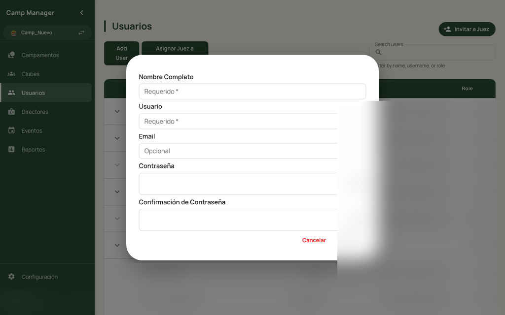

Formulario de creación de usuario

## 4.4 Ver rúbricas asignadas a un juez

Cada fila de usuario tiene un ícono de flecha (▼) a la izquierda que expande una sub-tabla con las rúbricas asignadas a ese juez.

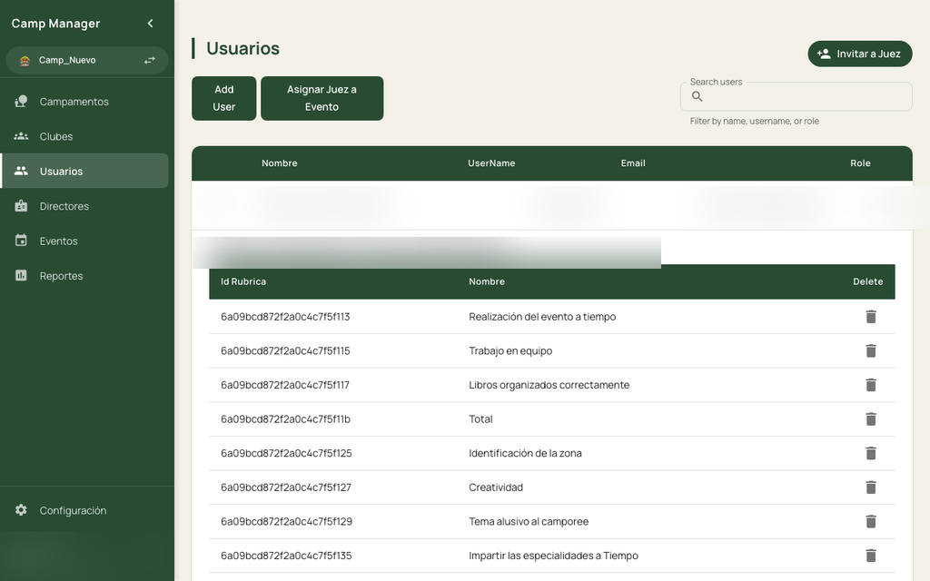

Fila expandida con rúbricas del juez

**Tip**

Para **asignar** rúbricas a un juez, usa el botón “Asignar Juez a Evento” desde esta misma vista, o hazlo directamente desde la sección Eventos.

## 4.5 Desasignar rúbrica de un juez

1. Expande la fila del juez haciendo clic en la flecha (▼)
2. Usa el filtro **“Filtrar por evento”** si necesitas localizar la rúbrica entre varios eventos
3. En la sub-tabla, haz clic en el ícono de papelera de la rúbrica que deseas desasignar
4. Se abre un diálogo de confirmación
5. Haz clic en **“Confirmar”** para eliminar la asignación

**Nota**

Desasignar una rúbrica no elimina las calificaciones ya registradas por ese juez.

**Tip**

También puedes desasignar jueces de una rúbrica desde la sección **Eventos**: expande el evento, abre el menú ⋮ de la rúbrica y selecciona **“Editar jueces”**. Esa vista permite gestionar todos los jueces de esa rúbrica al mismo tiempo.

# 5. Directores

Los directores son los responsables de los clubes participantes. Tienen acceso a un portal independiente (`/director/login`) donde pueden ver las calificaciones de su club. Desde esta sección del panel admin puedes gestionar sus cuentas: editar datos, restablecer contraseñas e importar directores en masa.

## 5.1 Ver directores

La tabla muestra todos los directores vinculados al campamento activo con las siguientes columnas:

| Columna | Descripción |
| --- | --- |
| **Nombre completo** | Nombre del director |
| **Usuario** | Nombre de usuario para iniciar sesión en el portal de directores |
| **Correo** | Email (opcional) |
| **Club** | Club al que pertenece el director |
| **Estado** | `Contraseña temporal` (naranja) — aún no cambió su acceso inicial; `Activo` (verde) — ya usa contraseña propia |
| **Acciones** | Ícono de lápiz (editar) e ícono de candado (restablecer contraseña) |

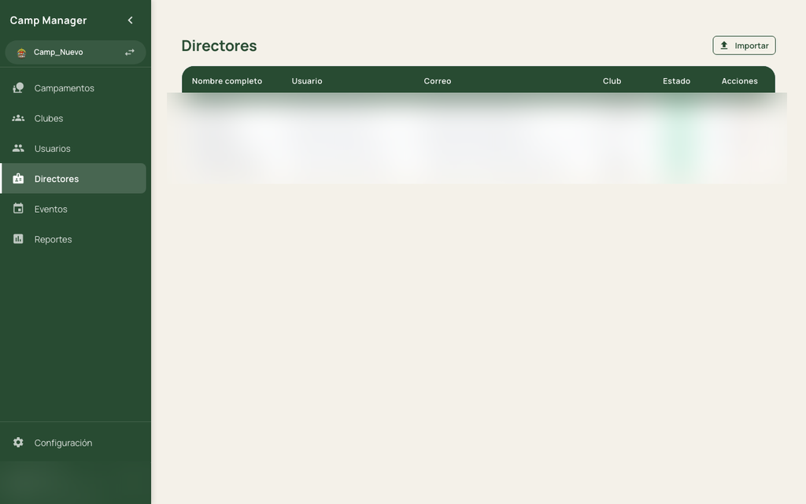

Lista de directores

**Tip**

El indicador **“Contraseña temporal”** es útil para saber quiénes todavía no completaron su primer acceso al portal.

## 5.2 Editar director

1. En la fila del director, haz clic en el ícono de lápiz (**Editar**)
2. Se abre un diálogo con los campos editables:
   - **Nombre completo**
   - **Usuario**
   - **Correo**
3. Modifica los valores necesarios y haz clic en **“Guardar”**

[figure not shown]

Formulario de edición de director

## 5.3 Restablecer contraseña

Si un director olvidó su contraseña o necesita un nuevo acceso:

1. En la fila del director, haz clic en el ícono de candado (**Restablecer contraseña**)
2. Se abre un diálogo de confirmación con el nombre del director
3. Haz clic en **“Confirmar”**
4. El sistema genera una contraseña temporal y la muestra en pantalla junto a un botón de copiar

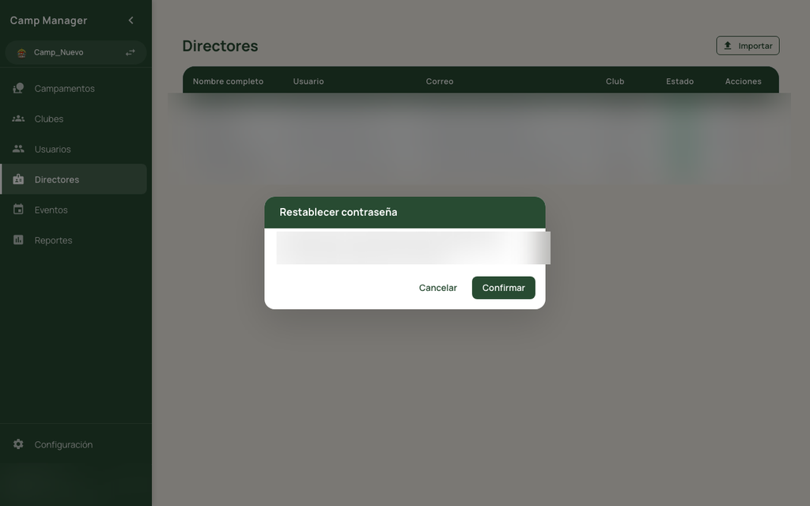

Diálogo de restablecimiento de contraseña

**Advertencia**

La contraseña temporal **solo se muestra una vez**. Cópiala antes de cerrar el diálogo y entrégasela al director. En su próximo ingreso al portal, el sistema le pedirá que la cambie.

## 5.4 Importación masiva

El botón **“Importar”** abre un wizard de 3 pasos para cargar múltiples directores desde un archivo Excel o CSV.

### Paso 1 — Subir archivo

- Arrastra el archivo al área indicada o haz clic para seleccionarlo
- Formatos aceptados: `.xlsx`, `.xls`, `.csv`
- Descarga la **plantilla Excel** con el botón “Descargar plantilla” para partir de un formato correcto

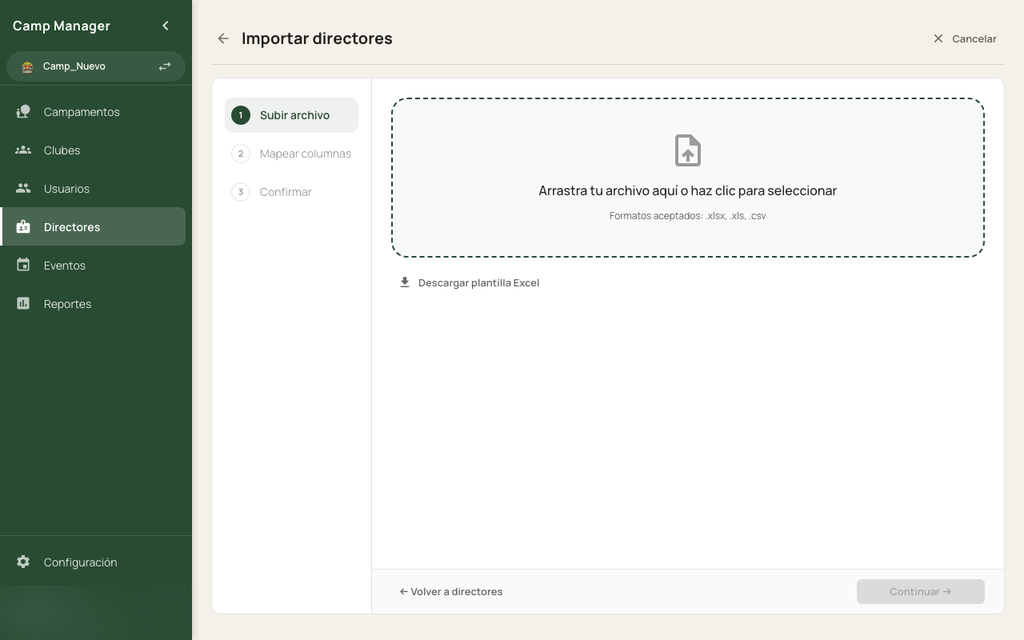

Wizard - Paso 1: subir archivo

### Paso 2 — Mapear columnas

El sistema detecta automáticamente qué columna del archivo corresponde a cada campo:

[output not shown]

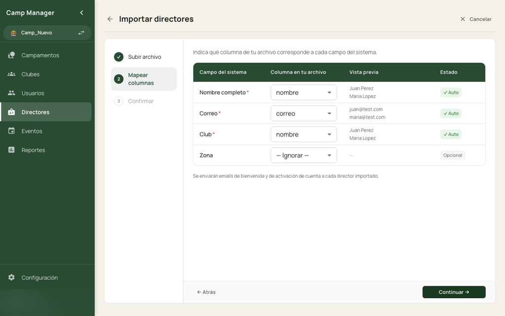

Wizard - Paso 2: mapeo de columnas

### Paso 3 — Confirmar

Antes de importar, el sistema muestra un resumen con la cantidad de directores a importar y una vista previa de las primeras filas. Haz clic en **“Importar N directores”** para confirmar.

**Nota**

Los directores importados reciben una contraseña temporal generada automáticamente. Deberán cambiarla en su primer acceso al portal. Usa la columna **Estado** de la tabla para hacer seguimiento.

# 6. Eventos y Rúbricas

Los eventos son las actividades que se califican durante el campamento. Cada evento tiene **rúbricas** (criterios de evaluación) y cada rúbrica puede asignarse a uno o más jueces. Los jueces califican desde la app móvil.

## 6.1 Ver eventos

La lista muestra todos los eventos del campamento activo. Cada fila es expandible y muestra las rúbricas del evento.

Sobre la tabla hay tres botones: - **Exportar** — descarga los eventos en formato Excel/CSV - **Importar** — carga eventos desde un archivo - **Nuevo evento** — abre el formulario de creación

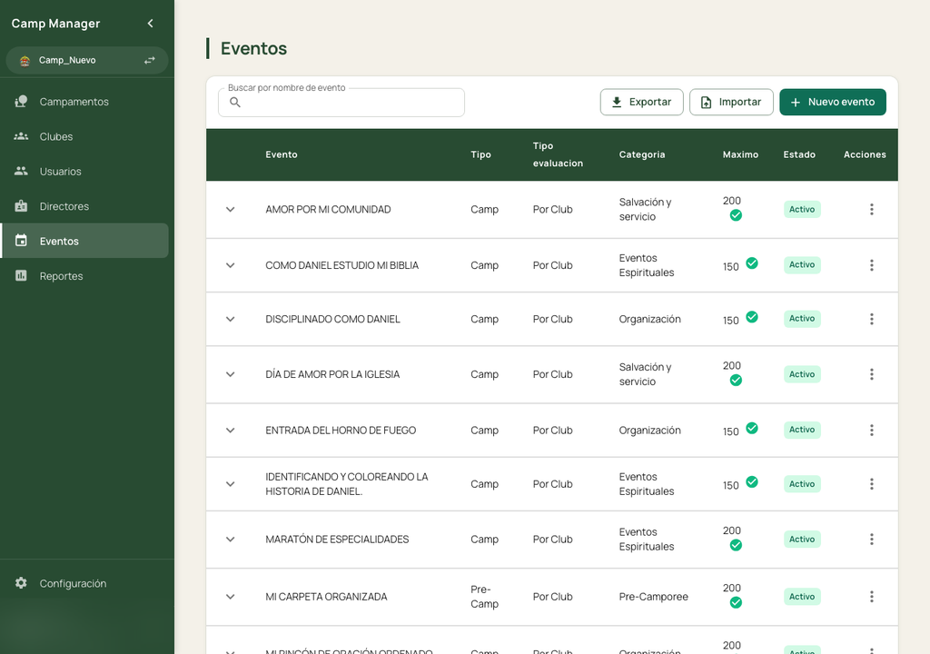

Lista de eventos

## 6.2 Crear evento

1. Haz clic en **“Nuevo evento”**
2. Completa los campos del formulario:

[output not shown]

3. En la sección **“Rubros iniciales del evento”** puedes agregar las rúbricas desde la creación:
   - Ingresa el nombre y puntaje máximo de cada rubro
   - Marca **“Incluido en suma”** si el rubro debe contarse en el total
   - Marca **“Permite negativo”** si puede restarse del puntaje
   - Haz clic en **“Agregar rubro”** para añadirlo a la lista
   - El sistema valida que la suma de los rubros incluidos coincida con el máximo del evento
4. Haz clic en **“Guardar”**

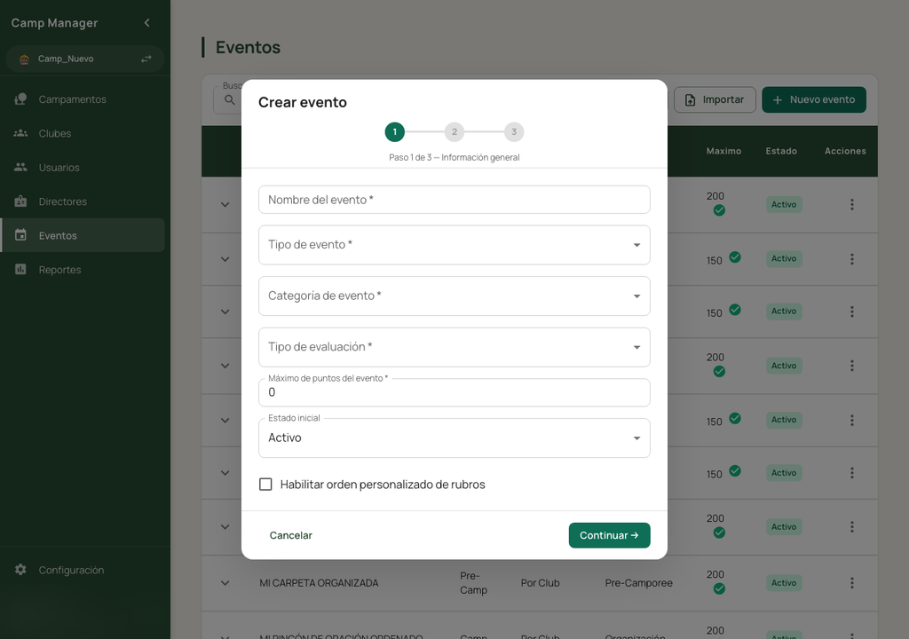

Formulario de creación de evento

**Nota**

Los eventos de tipo **Inspección** tienen comportamiento especial en los reportes de calificaciones generales.

## 6.3 Ver rúbricas de un evento

Haz clic en la flecha (▼) de la fila del evento para expandirla y ver sus rúbricas. La sub-tabla muestra:

| Columna | Descripción |
| --- | --- |
| **Ord.** | Número de orden de la rúbrica |
| **Nombre** | Nombre de la rúbrica/criterio |
| **Max.** | Puntaje máximo que puede obtener |
| **Incluye suma** | Si se cuenta en el total del evento |
| **Permite negativo** | Si puede tener puntaje negativo |
| **Acciones** | Botón ⋮ con menú de opciones: Editar rubro, Editar jueces, Eliminar rubro |

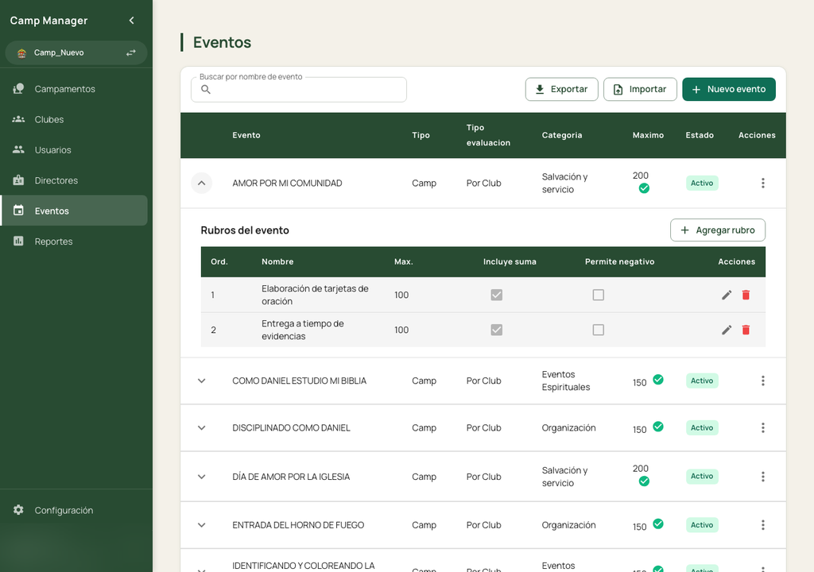

Vista detalle del evento con rúbricas

**Nota**

## 6.4 Agregar rúbrica a un evento existente

1. Expande el evento haciendo clic en la flecha (▼)
2. Haz clic en **“Agregar rubro”** (esquina superior derecha de la sub-tabla)
3. Completa el formulario de rúbrica:
   - **Nombre** *(obligatorio)*
   - **Puntaje máximo** *(obligatorio)*
   - **Incluido en suma** — si contribuye al total del evento
   - **Permite negativo** — si puede restar puntos
   - **Instrucciones** *(opcional)* — guía para el juez al calificar
4. Haz clic en **“Guardar”**

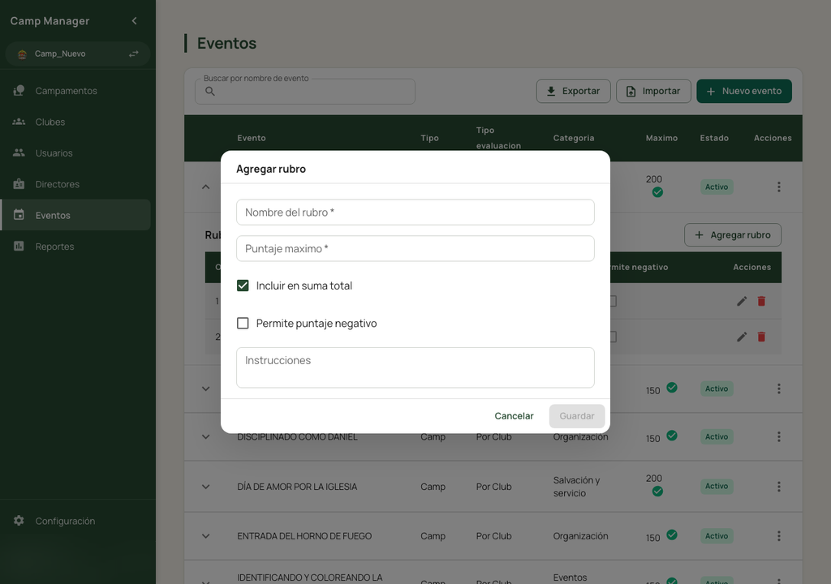

Formulario de creación de rúbrica

**Advertencia**

El total de puntos de los rubros incluidos en suma debe coincidir con el máximo del evento. Si no coinciden, el sistema muestra un error y no permite guardar.

## 6.5 Asignar juez a una rúbrica

La asignación de jueces se hace desde la sección **Usuarios**:

1. Ve a **Usuarios** en el menú lateral
2. Haz clic en **“Asignar Juez a Evento”**
3. En el formulario:
   - **Evento** — selecciona el evento
   - **Juez** — selecciona el o los jueces del campamento
   - **Rúbricas** — marca las rúbricas que calificará ese juez
4. Haz clic en **“Guardar”**

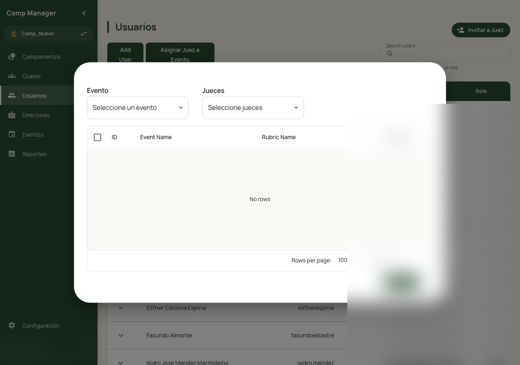

Formulario de asignación de juez a rúbricas

**Nota**

Un juez solo verá en su app móvil las rúbricas que le fueron asignadas. Puedes asignar múltiples jueces a una misma rúbrica.

## 6.6 Editar jueces de una rúbrica

Desde la sub-tabla de rúbricas de un evento puedes ver y gestionar qué jueces están asignados a cada rúbrica individual, y remover los que ya no deben calificarla.

1. Expande el evento haciendo clic en la flecha (▼)
2. En la fila de la rúbrica, haz clic en el botón ⋮ y selecciona **“Editar jueces”**
3. Se abre el diálogo **“Editar jueces — [Nombre del rubro]”** con la lista de jueces actualmente asignados
4. Para quitar un juez, haz clic en el ícono de papelera a la derecha de su fila:
   - La fila se marca visualmente con **fondo rojo**, texto tachado y opacidad reducida (el cambio aún no se aplica)
   - El ícono cambia a **“Deshacer”** — haz clic en él si cambias de opinión
5. Un banner amarillo al pie del diálogo indica cuántos jueces serán removidos al guardar
6. Haz clic en **“Guardar”** para aplicar los cambios; haz clic en **“Cancelar”** para descartarlos

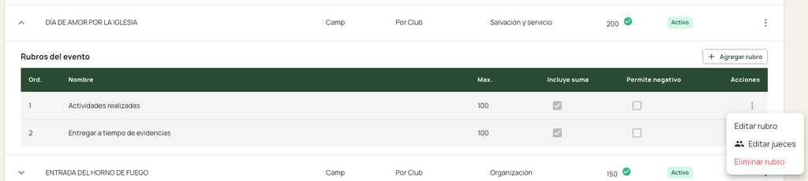

Menú de acciones de rúbrica con opción Editar jueces

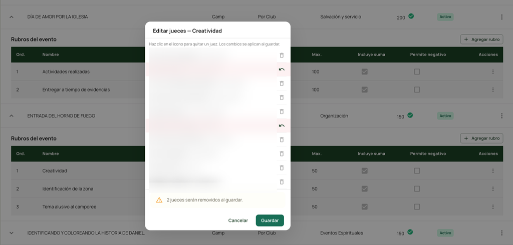

Diálogo de edición de jueces con soft-delete visual

**Nota**

Los jueces se ordenan alfabéticamente. Un juez marcado para remover todavía aparece en la lista hasta que presionas “Guardar”, de modo que puedes revisar todos los cambios antes de confirmar.

**Advertencia**

Remover un juez de una rúbrica **no elimina las calificaciones** que ese juez ya registró. Solo lo desvincula de la rúbrica para futuros accesos desde la app móvil.

## 6.7 Desasignar todos los jueces de un evento

Desde la lista de eventos, el menú de tres puntos (⋮) de cada **fila de evento** incluye la opción **“Desasignar usuarios de rubros”**, que remueve todos los jueces asignados a todas las rúbricas de ese evento de una sola vez.

**Tip**

Para remover un juez de una sola rúbrica sin afectar las demás, usa la opción **“Editar jueces”** del menú ⋮ de esa rúbrica (ver sección anterior). Para removerlo desde la vista de usuarios, expande la fila del juez y usa el ícono de papelera junto a la rúbrica.

## 6.8 Importar eventos con ayuda de IA

Cuando el campamento ya tiene instructivos o manuales de sus eventos (ya sea en papel o en PDF), puedes fotografiarlos o capturar pantalla y usar una IA con visión para convertirlos en JSON automáticamente. Luego importas todos los eventos de una sola vez, sin tipear cada uno a mano.

### Paso 1 — Reúne los instructivos

Prepara una imagen por cada evento que quieras cargar:

- Toma una foto con el celular al instructivo impreso, o
- Captura pantalla del PDF o documento digital

Cada imagen debe mostrar claramente el **nombre del evento**, los **criterios de evaluación** (rubros) y el **puntaje de cada uno**.

### Paso 2 — Abre una IA con visión y pega el prompt

Abre una de estas IAs que soportan análisis de imágenes:

- **ChatGPT** (GPT-4o) → chat.openai.com
- **Claude** → claude.ai
- **Gemini** → gemini.google.com

Copia el siguiente prompt completo y pégalo como **primer mensaje** de la conversación (sin adjuntar ninguna imagen todavía):

```
Eres un asistente que lee instructivos de eventos de campamento y los convierte en objetos JSON para importar en Camp Manager, un sistema de gestión de campamentos.

Por cada imagen que te envíe, extrae la información del evento y devuelve ÚNICAMENTE un objeto JSON con este formato exacto:

{
  "name": "Nombre del evento",
  "event_type": "Camp",
  "evaluation_type": "Por Club",
  "event_category": "Recreativos",
  "maxPointEvents": 100,
  "status": true,
  "rubricsCustomOrder": false,
  "rubrics": [
    {
      "name": "Nombre del criterio",
      "maxPoints": 60,
      "includedInSum": true,
      "allowNegative": false,
      "instructions": "Instrucciones para el juez",
      "displayedOrder": 1
    },
    {
      "name": "Segundo criterio",
      "maxPoints": 40,
      "includedInSum": true,
      "allowNegative": false,
      "instructions": "",
      "displayedOrder": 2
    }
  ]
}

---

DESCRIPCIÓN DE CADA CAMPO:

- name (texto): Nombre del evento tal como aparece en el instructivo.

- event_type (texto): Fase del evento. Elige EXACTAMENTE uno de los siguientes valores:
    "Pre-Camp"   → actividad que ocurre antes del inicio del campamento
```

[output cut: 27 more lines]

```
    - maxPoints: Puntaje máximo de ese criterio.
    - includedInSum: true si ese criterio suma al total del evento; false si es referencial.
    - allowNegative: true solo si el criterio puede restar puntos al total.
    - instructions: Copia textual de las instrucciones para el juez que aparecen en el instructivo. Deja "" si no hay instrucciones.
    - displayedOrder: Número de orden del criterio (empieza en 1).

---

REGLAS OBLIGATORIAS:

1. Los valores de event_type, evaluation_type y event_category deben coincidir EXACTAMENTE con las opciones listadas (respeta mayúsculas, minúsculas y tildes).
2. La suma de maxPoints de todos los rubros donde includedInSum es true DEBE ser igual a maxPointEvents.
3. NO incluyas los campos "camp" ni "leadJudge". El sistema los agrega automáticamente.
4. Responde únicamente con el objeto JSON, sin texto adicional ni explicaciones.
5. Cuando yo escriba la palabra "LISTO", combina todos los objetos JSON que generaste en este chat dentro de un array [ {...}, {...}, ... ] y devuelve ese array completo.
```

### Paso 3 — Envía las imágenes una por una

Una vez que la IA haya confirmado que entendió el prompt:

1. Adjunta la **fotografía o captura** del primer instructivo y envíala
2. La IA devolverá el objeto JSON de ese evento — revísalo para confirmar que los campos sean correctos
3. **Copia el JSON** en un bloc de notas o editor de texto
4. Repite el proceso con el siguiente instructivo
5. Cuando hayas procesado todos los eventos, escribe **“LISTO”** — la IA combinará todos los objetos en un array

**Tip**

Revisa cada JSON antes de acumular: verifica que `event_category` sea la categoría correcta y que los `maxPoints` de los rubros sumen exactamente el `maxPointEvents` del evento.

### Paso 4 — Importa el JSON al sistema

1. Copia el array completo `[{...}, {...}, ...]` que devolvió la IA
2. Pégalo en un editor de texto y guárdalo como un archivo con extensión `.json` (por ejemplo: `eventos-camporee-2025.json`)
3. En Camp Manager, ve a **Eventos** en el menú lateral
4. Haz clic en el botón **“Importar”**
5. Selecciona el archivo `.json` que guardaste
6. Revisa el resumen: el sistema muestra cuántos eventos serán creados y si alguno tuvo errores de nombre
7. Haz clic en **“Importar X eventos”** para confirmar

**Advertencia**

Los valores de `event_type`, `evaluation_type` y `event_category` deben coincidir **exactamente** con los nombres del sistema, incluyendo tildes y mayúsculas. Si alguno no coincide, ese evento será omitido y aparecerá como error en el resumen de importación.

**Nota**

Los eventos de tipo **`Inspeccion`** tienen comportamiento especial: no se incluyen en los reportes de calificaciones generales y se procesan por separado en el reporte de inspecciones.

### JSON de referencia (estructura completa)

Usa esto como plantilla si necesitas crear o editar el JSON manualmente:

```json
[
  {
    "name": "Nombre del Evento",
    "event_type": "Camp",
    "evaluation_type": "Por Club",
    "event_category": "Recreativos",
    "maxPointEvents": 100,
    "status": true,
    "rubricsCustomOrder": false,
    "rubrics": [
      {
        "name": "Primer criterio de evaluación",
        "maxPoints": 60,
        "includedInSum": true,
        "allowNegative": false,
        "instructions": "Instrucciones opcionales para el juez",
        "displayedOrder": 1
      },
      {
        "name": "Segundo criterio de evaluación",
        "maxPoints": 40,
        "includedInSum": true,
        "allowNegative": false,
        "instructions": "",
        "displayedOrder": 2
      }
    ]
  }
]
```

| Campo | Tipo | Descripción |
| --- | --- | --- |
| `name` | texto | Nombre del evento |
| `event_type` | texto | `"Pre-Camp"`, `"Camp"` o `"Inspeccion"` |
| `evaluation_type` | texto | `"Por Club"` o `"Por Zona"` |
| `event_category` | texto | Una de las 10 categorías del sistema |
| `maxPointEvents` | número | Puntaje máximo total del evento |
| `status` | booleano | `true` = activo |
| `rubricsCustomOrder` | booleano | `true` activa ordenamiento manual de rubros |
| `rubrics[].name` | texto | Nombre del criterio/rubro |
| `rubrics[].maxPoints` | número | Puntaje máximo del criterio |
| `rubrics[].includedInSum` | booleano | `true` = cuenta en el total del evento |
| `rubrics[].allowNegative` | booleano | `true` = puede restar puntos |
| `rubrics[].instructions` | texto | Guía para el juez al calificar |
| `rubrics[].displayedOrder` | número | Orden de visualización (empieza en 1) |

# 7. Reportes

El módulo de Reportes centraliza todas las vistas analíticas del campamento. Hay **11 tipos de reporte**, accesibles desde el menú lateral bajo “Reportes”. Cada reporte opera sobre el campamento activo seleccionado.

## 7.1 Detalles de Calificaciones por Rúbricas

**Ruta:** `/reports/rubrics-grades-details`

Vista de granularidad máxima: muestra cada calificación individual a nivel de rúbrica, con el comentario y el juez que la registró.

### Columnas

[output not shown]

### Filtros disponibles

- **Evento** — desplegable con todos los eventos del campamento
- **Zona** — filtra por afiliación
- **Club** — filtra por club
- **Evaluado Por** — filtra por juez
- **Comentarios** — muestra solo filas con o sin comentario

Haz clic en **“Limpiar filtros”** para restablecer todos los filtros.

### Exportar

El botón **“Exportar CSV”** descarga la tabla filtrada en formato CSV.

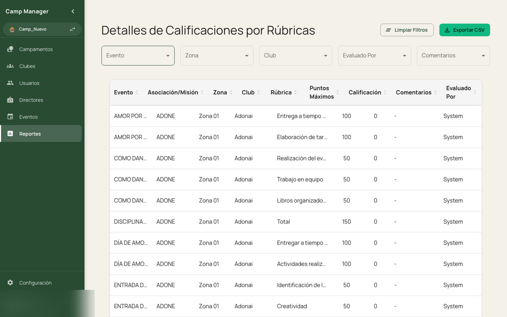

Reporte: Detalles de rúbricas

## 7.2 Puntuación General

**Ruta:** `/reports/notas-generales`

Resumen de calificaciones por evento y club (una fila por calificación registrada).

### Filtros disponibles

- **Evento**
- **Misión / Zona**
- **Club**
- **Calificación** — valor numérico exacto

Las columnas son ordenables haciendo clic en el encabezado (alterna ascendente/descendente).

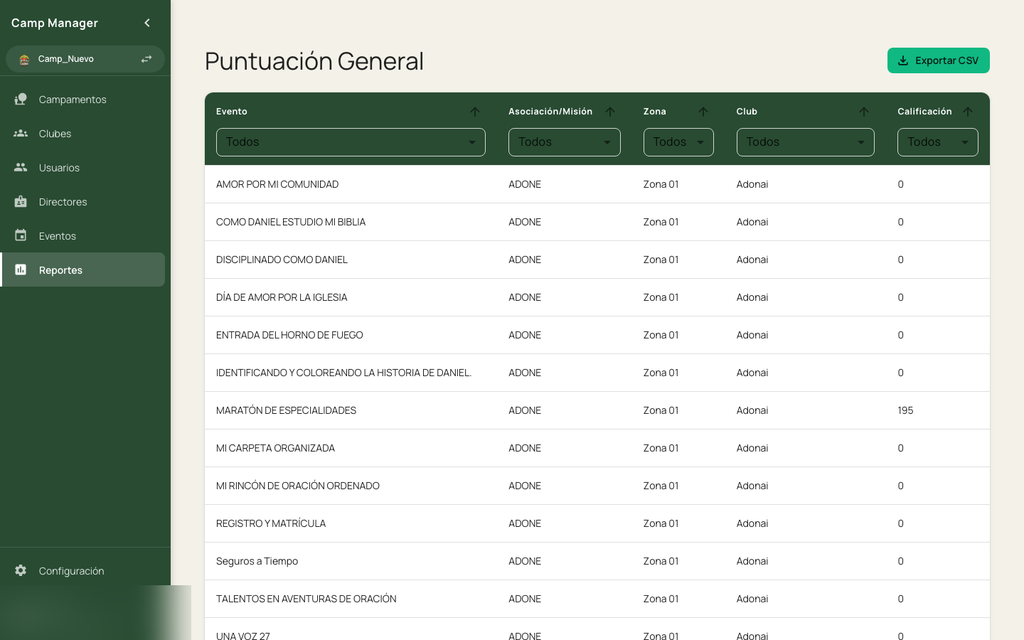

Reporte: Puntuación general